# Question

A **horizontal hyperbola** has two curves facing East and West (like `)(` ). There is a center $(h,k)$, transverse semi-axis $a$, and conjugate semi-axis $b$. A horizontal hyperbola is the set of points satisfying the equation below.

$$\frac{(x-h)^2}{a^2}-\frac{(y-k)^2}{b^2}=1$$

A **vertical hyperbola** has two curves facing North and South (like $\asymp$ ). There is a center $(h,k)$, transverse semi-axis $a$, and conjugate semi-axis $b$. A vertical hyperbola is the set of points satisfying the equation below.

$$\frac{(y-k)^2}{a^2}-\frac{(x-h)^2}{b^2}=1$$

Determine whether the following are horizontal or vertical.

## A

Is the hyperbola represented below horizontal or vertical?

$$-\frac{(x+3)^2}{4}+\frac{(y-5)^2}{16}=1$$

The hyperbola represented above is ##ANSWER1##

## B

Is the hyperbola represented below horizontal or vertical?

$$\frac{(x-2)^2}{16}-\frac{(y-3)^2}{36}=1$$

The hyperbola represented above is ##ANSWER2##

## C

Is the hyperbola represented below horizontal or vertical?

$$\frac{(x-4)^2}{25}-\frac{(y-6)^2}{9}=1$$

The hyperbola represented above is ##ANSWER3##

## D

Is the hyperbola represented below horizontal or vertical?

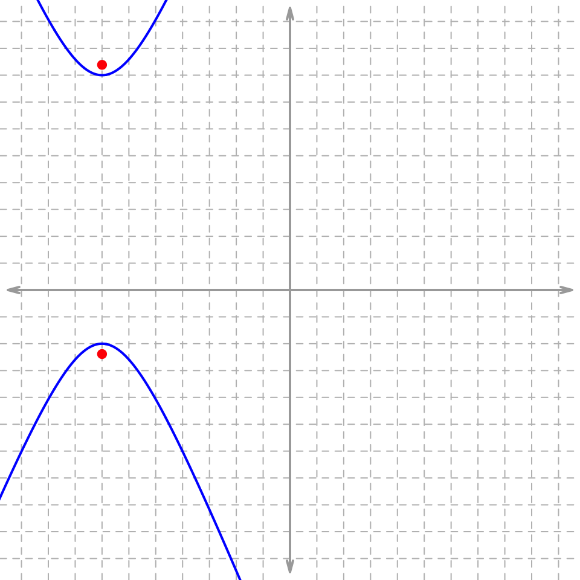

The hyperbola represented above is ##ANSWER4##

## E

Is the hyperbola represented below horizontal or vertical?

$$-\frac{(x-3)^2}{36}+\frac{(y+2)^2}{25}=1$$

The hyperbola represented above is ##ANSWER5##

## F

Is the hyperbola represented below horizontal or vertical?

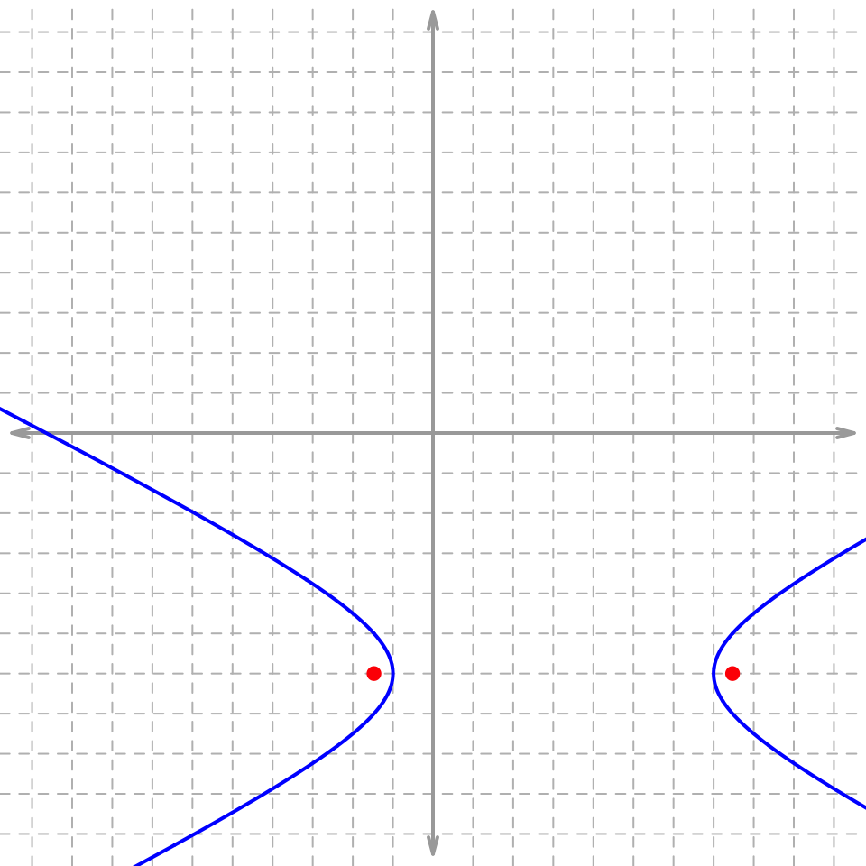

The hyperbola represented above is ##ANSWER6##

## Answerlist

- horizontal
- vertical
- horizontal
- vertical
- horizontal
- vertical
- horizontal
- vertical
- horizontal
- vertical
- horizontal
- vertical

# Solution

The graphs should be pretty easy. `)(` is horizontal and $\asymp$ is vertical.

The equations can be a bit tricky, because the order of the fractions is randomized. **Pay attention to which fraction (containing $x$ or $y$) has the negative sign.**

Personally, I think about $x$ and $y$ values that make the numerators 0. Then I think if there could be any solutions. The key idea is that there are no real $n$ and $d$ such that $-\frac{n^2}{d^2}=1$. If there are $x$ values that have no solution (no corresponding $y$ to make the equation true), then there are vertical lines that do not hit the hyperbola, meaning the hyperbola must be horizontal. If there are $y$ values that have no solution, then there are horizontal lines that do not hit the hyperbola, meaning the hyperbola must be vertical. I know that is convoluted, but I’ve yet to find a more robust way to store this in my long-term memory.

- Representation $A$ is of a vertical hyperbola.
- Representation $B$ is of a horizontal hyperbola.
- Representation $C$ is of a horizontal hyperbola.
- Representation $D$ is of a vertical hyperbola.
- Representation $E$ is of a vertical hyperbola.
- Representation $F$ is of a horizontal hyperbola.

# Meta-information

extype: cloze exclozetype: schoice|schoice|schoice|schoice|schoice|schoice exsolution: 01|10|10|01|01|10 exname: hyp_hor_or_ver